# SCZ Climate Trends

Teresa Fukuda

4/6/2020

## ESM237 Assignment #1

### Introduction.

Santa Cruz is a coastal town located on the Northern edge of the Monterey Bay in California. It is largely urban, but is surrounded by coastline to the South, wooded hills to the North and East, and smaller neighboring towns. The climate is temperate and Mediterranean, with cool, wet winters and warm, dry summers. Summers are foggy, providing moisture for coastal redwood forests and other local ecosystems. The economy is Santa Cruz is partially dependent on tourism brought in by the natural resources, including beaches, word-class surfing, mountain biking, and hiking. The surrounding communities rely heavily on agriculture. The water supply for the City comes from mostly from a local reservoir that relies on local precipitation, but is also supplemented by a few wells and some small creeks.

[figure not shown]

Figure 1. Map of Monterey Bay highlighting location of Santa Cruz County (left) and map of California to show location within the state.

As the climate changes, some important impacts include changing precipitation amounts affecting rainfall, agriculture, and flooding; increased temperatures causing ecosystem harm, higher fire danger, and changing human behavior; and sea level rise which can cause coastal flooding and cliff erosion.

### Climate trends.

I conducted an analysis of one long-term climate dataset for Santa Cruz (Station name: SANTA CRUZ, CA US ; Network:ID GHCND:USC00047916) from [NOAA NCEI CDO](https://www.ncdc.noaa.gov/cdo-web/datatools/findstation) looking at temperature and precipitation trends from 1920 to 2019. In this report I will explore trends over this time period in average daily temperature, average yearly rainfall, and annual temperature extremes.

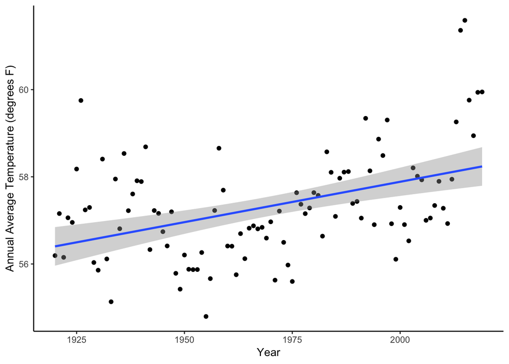

Figure 2. Average daily temperature aggregated as an average over each year in Santa Cruz. Trend line shown as linear model, with a slope of 0.02317 and p=1.17e-06.

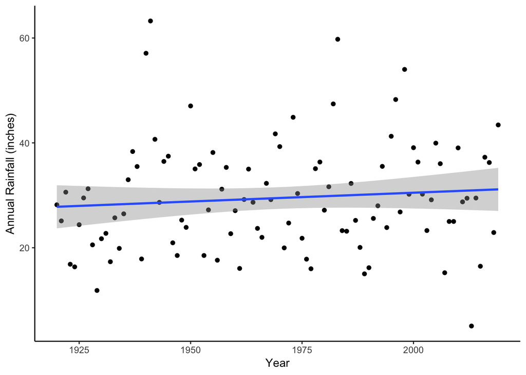

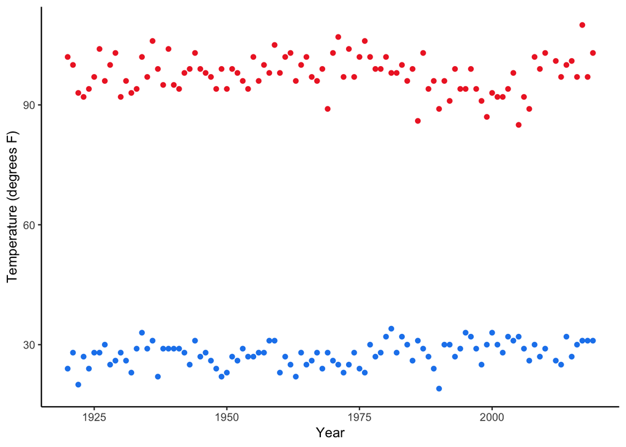

Figure 4. Annual maximum and minimum temperatures in Santa Cruz from 1920 to 2019. Red points show the maximum temperatures and blue points show minimum temperatures.

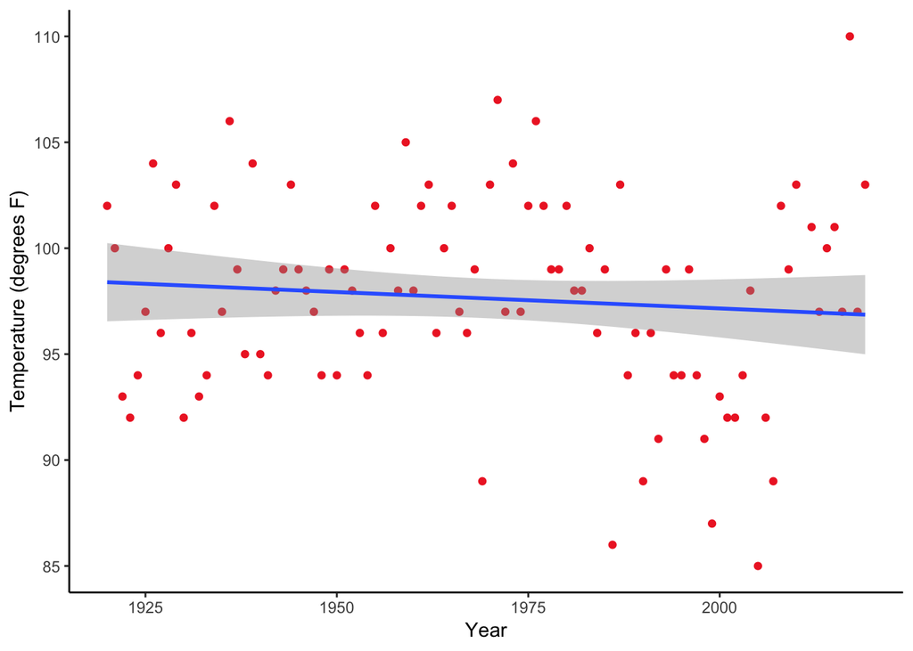

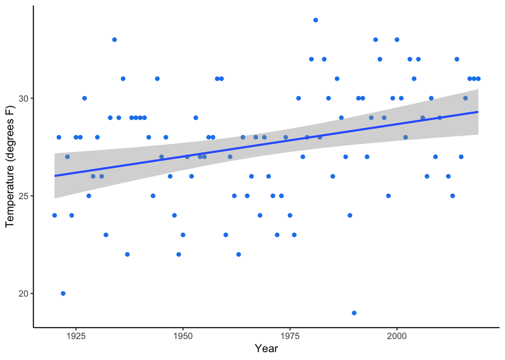

Figure 6. Annual minimum temperature values in Santa Cruz from 1920 to 2019. The blue line is a linear regression fit to the data with slope of 0.03595, p=0.000544.

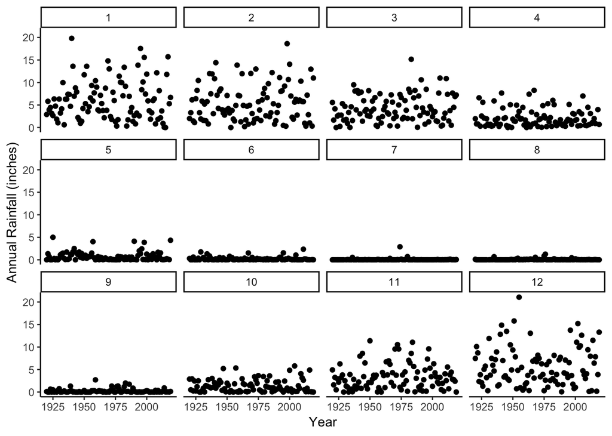

Figure 7. Average annual rainfall in inches, shown for each month from 1920 to 2019. The numerical values at the top of each scatterplot indicate the month.